# Risk Factor Analysis

## Outcome Variable

**Outcome Variable:** wast_rec90d

## Predictor Variables

**Intervention Variable:** mhtcm

**Adjustment Set:**

- arm
- W_mage
- meducyrs
- feducyrs
- delta_W_mage
- delta_meducyrs
- delta_feducyrs

## Stratifying Variables

The analysis was stratified on these variable(s):

- agecat
- studyid
- country

## Data Summary

| agecat | studyid | country | mhtcm | wast_rec90d | n_cell | n |
| --- | --- | --- | --- | --- | --- | --- |
| 0-24 months | ki0047075b-MAL-ED | BANGLADESH | >=155 cm | 0 | 4 | 122 |
| 0-24 months | ki0047075b-MAL-ED | BANGLADESH | >=155 cm | 1 | 5 | 122 |
| 0-24 months | ki0047075b-MAL-ED | BANGLADESH | <151 cm | 0 | 32 | 122 |
| 0-24 months | ki0047075b-MAL-ED | BANGLADESH | <151 cm | 1 | 52 | 122 |
| 0-24 months | ki0047075b-MAL-ED | BANGLADESH | [151-155) cm | 0 | 7 | 122 |
| 0-24 months | ki0047075b-MAL-ED | BANGLADESH | [151-155) cm | 1 | 22 | 122 |
| 0-24 months | ki0047075b-MAL-ED | BRAZIL | >=155 cm | 0 | 5 | 24 |
| 0-24 months | ki0047075b-MAL-ED | BRAZIL | >=155 cm | 1 | 13 | 24 |
| 0-24 months | ki0047075b-MAL-ED | BRAZIL | <151 cm | 0 | 1 | 24 |
| 0-24 months | ki0047075b-MAL-ED | BRAZIL | <151 cm | 1 | 4 | 24 |
| 0-24 months | ki0047075b-MAL-ED | BRAZIL | [151-155) cm | 0 | 0 | 24 |
| 0-24 months | ki0047075b-MAL-ED | BRAZIL | [151-155) cm | 1 | 1 | 24 |
| 0-24 months | ki0047075b-MAL-ED | INDIA | >=155 cm | 0 | 12 | 178 |
| 0-24 months | ki0047075b-MAL-ED | INDIA | >=155 cm | 1 | 18 | 178 |
| 0-24 months | ki0047075b-MAL-ED | INDIA | <151 cm | 0 | 44 | 178 |
| 0-24 months | ki0047075b-MAL-ED | INDIA | <151 cm | 1 | 50 | 178 |
| 0-24 months | ki0047075b-MAL-ED | INDIA | [151-155) cm | 0 | 14 | 178 |
| 0-24 months | ki0047075b-MAL-ED | INDIA | [151-155) cm | 1 | 40 | 178 |
| 0-24 months | ki0047075b-MAL-ED | NEPAL | >=155 cm | 0 | 3 | 98 |
| 0-24 months | ki0047075b-MAL-ED | NEPAL | >=155 cm | 1 | 9 | 98 |
| 0-24 months | ki0047075b-MAL-ED | NEPAL | <151 cm | 0 | 14 | 98 |
| 0-24 months | ki0047075b-MAL-ED | NEPAL | <151 cm | 1 | 46 | 98 |
| 0-24 months | ki0047075b-MAL-ED | NEPAL | [151-155) cm | 0 | 3 | 98 |
| 0-24 months | ki0047075b-MAL-ED | NEPAL | [151-155) cm | 1 | 23 | 98 |
| 0-24 months | ki0047075b-MAL-ED | PERU | >=155 cm | 0 | 0 | 35 |
| 0-24 months | ki0047075b-MAL-ED | PERU | >=155 cm | 1 | 3 | 35 |
| 0-24 months | ki0047075b-MAL-ED | PERU | <151 cm | 0 | 4 | 35 |
| 0-24 months | ki0047075b-MAL-ED | PERU | <151 cm | 1 | 24 | 35 |
| 0-24 months | ki0047075b-MAL-ED | PERU | [151-155) cm | 0 | 2 | 35 |
| 0-24 months | ki0047075b-MAL-ED | PERU | [151-155) cm | 1 | 2 | 35 |

[output cut: 378 more lines]

The following strata were considered:

- agecat: 0-24 months, studyid: ki0047075b-MAL-ED, country: BANGLADESH
- agecat: 0-24 months, studyid: ki0047075b-MAL-ED, country: BRAZIL
- agecat: 0-24 months, studyid: ki0047075b-MAL-ED, country: INDIA
- agecat: 0-24 months, studyid: ki0047075b-MAL-ED, country: NEPAL
- agecat: 0-24 months, studyid: ki0047075b-MAL-ED, country: PERU
- agecat: 0-24 months, studyid: ki0047075b-MAL-ED, country: SOUTH AFRICA
- agecat: 0-24 months, studyid: ki0047075b-MAL-ED, country: TANZANIA, UNITED REPUBLIC OF
- agecat: 0-24 months, studyid: ki1000304b-SAS-CompFeed, country: INDIA
- agecat: 0-24 months, studyid: ki1000304b-SAS-FoodSuppl, country: INDIA
- agecat: 0-24 months, studyid: ki1017093-NIH-Birth, country: BANGLADESH
- agecat: 0-24 months, studyid: ki1017093b-PROVIDE, country: BANGLADESH
- agecat: 0-24 months, studyid: ki1017093c-NIH-Crypto, country: BANGLADESH
- agecat: 0-24 months, studyid: ki1066203-TanzaniaChild2, country: TANZANIA, UNITED REPUBLIC OF
- agecat: 0-24 months, studyid: ki1101329-Keneba, country: GAMBIA
- agecat: 0-24 months, studyid: ki1112895-Guatemala BSC, country: GUATEMALA
- agecat: 0-24 months, studyid: ki1112895-iLiNS-Zinc, country: BURKINA FASO
- agecat: 0-24 months, studyid: ki1119695-PROBIT, country: BELARUS
- agecat: 0-24 months, studyid: ki1126311-ZVITAMBO, country: ZIMBABWE
- agecat: 0-24 months, studyid: ki1135781-COHORTS, country: GUATEMALA
- agecat: 0-24 months, studyid: ki1135781-COHORTS, country: INDIA
- agecat: 0-24 months, studyid: ki1135781-COHORTS, country: PHILIPPINES
- agecat: 0-24 months, studyid: ki1148112-LCNI-5, country: MALAWI
- agecat: 0-24 months, studyid: kiGH5241-JiVitA-3, country: BANGLADESH
- agecat: 0-6 months, studyid: ki0047075b-MAL-ED, country: BANGLADESH
- agecat: 0-6 months, studyid: ki0047075b-MAL-ED, country: BRAZIL
- agecat: 0-6 months, studyid: ki0047075b-MAL-ED, country: INDIA
- agecat: 0-6 months, studyid: ki0047075b-MAL-ED, country: NEPAL
- agecat: 0-6 months, studyid: ki0047075b-MAL-ED, country: PERU
- agecat: 0-6 months, studyid: ki0047075b-MAL-ED, country: SOUTH AFRICA
- agecat: 0-6 months, studyid: ki0047075b-MAL-ED, country: TANZANIA, UNITED REPUBLIC OF
- agecat: 0-6 months, studyid: ki1000304b-SAS-CompFeed, country: INDIA
- agecat: 0-6 months, studyid: ki1000304b-SAS-FoodSuppl, country: INDIA
- agecat: 0-6 months, studyid: ki1017093-NIH-Birth, country: BANGLADESH
- agecat: 0-6 months, studyid: ki1017093b-PROVIDE, country: BANGLADESH
- agecat: 0-6 months, studyid: ki1017093c-NIH-Crypto, country: BANGLADESH
- agecat: 0-6 months, studyid: ki1066203-TanzaniaChild2, country: TANZANIA, UNITED REPUBLIC OF
- agecat: 0-6 months, studyid: ki1101329-Keneba, country: GAMBIA
- agecat: 0-6 months, studyid: ki1112895-Guatemala BSC, country: GUATEMALA
- agecat: 0-6 months, studyid: ki1119695-PROBIT, country: BELARUS
- agecat: 0-6 months, studyid: ki1126311-ZVITAMBO, country: ZIMBABWE
- agecat: 0-6 months, studyid: ki1135781-COHORTS, country: GUATEMALA
- agecat: 0-6 months, studyid: ki1135781-COHORTS, country: INDIA
- agecat: 0-6 months, studyid: ki1135781-COHORTS, country: PHILIPPINES
- agecat: 0-6 months, studyid: ki1148112-LCNI-5, country: MALAWI
- agecat: 0-6 months, studyid: kiGH5241-JiVitA-3, country: BANGLADESH
- agecat: 6-24 months, studyid: ki0047075b-MAL-ED, country: BANGLADESH
- agecat: 6-24 months, studyid: ki0047075b-MAL-ED, country: BRAZIL
- agecat: 6-24 months, studyid: ki0047075b-MAL-ED, country: INDIA
- agecat: 6-24 months, studyid: ki0047075b-MAL-ED, country: NEPAL
- agecat: 6-24 months, studyid: ki0047075b-MAL-ED, country: PERU
- agecat: 6-24 months, studyid: ki0047075b-MAL-ED, country: SOUTH AFRICA
- agecat: 6-24 months, studyid: ki0047075b-MAL-ED, country: TANZANIA, UNITED REPUBLIC OF
- agecat: 6-24 months, studyid: ki1000304b-SAS-CompFeed, country: INDIA
- agecat: 6-24 months, studyid: ki1000304b-SAS-FoodSuppl, country: INDIA
- agecat: 6-24 months, studyid: ki1017093-NIH-Birth, country: BANGLADESH
- agecat: 6-24 months, studyid: ki1017093b-PROVIDE, country: BANGLADESH
- agecat: 6-24 months, studyid: ki1017093c-NIH-Crypto, country: BANGLADESH
- agecat: 6-24 months, studyid: ki1066203-TanzaniaChild2, country: TANZANIA, UNITED REPUBLIC OF
- agecat: 6-24 months, studyid: ki1101329-Keneba, country: GAMBIA
- agecat: 6-24 months, studyid: ki1112895-Guatemala BSC, country: GUATEMALA
- agecat: 6-24 months, studyid: ki1112895-iLiNS-Zinc, country: BURKINA FASO
- agecat: 6-24 months, studyid: ki1119695-PROBIT, country: BELARUS
- agecat: 6-24 months, studyid: ki1126311-ZVITAMBO, country: ZIMBABWE
- agecat: 6-24 months, studyid: ki1135781-COHORTS, country: GUATEMALA
- agecat: 6-24 months, studyid: ki1135781-COHORTS, country: INDIA
- agecat: 6-24 months, studyid: ki1135781-COHORTS, country: PHILIPPINES
- agecat: 6-24 months, studyid: ki1148112-LCNI-5, country: MALAWI
- agecat: 6-24 months, studyid: kiGH5241-JiVitA-3, country: BANGLADESH

### Dropped Strata

Some strata were dropped due to rare outcomes:

- agecat: 0-24 months, studyid: ki0047075b-MAL-ED, country: BANGLADESH
- agecat: 0-24 months, studyid: ki0047075b-MAL-ED, country: BRAZIL
- agecat: 0-24 months, studyid: ki0047075b-MAL-ED, country: NEPAL
- agecat: 0-24 months, studyid: ki0047075b-MAL-ED, country: PERU
- agecat: 0-24 months, studyid: ki0047075b-MAL-ED, country: SOUTH AFRICA
- agecat: 0-24 months, studyid: ki0047075b-MAL-ED, country: TANZANIA, UNITED REPUBLIC OF
- agecat: 0-24 months, studyid: ki1000304b-SAS-FoodSuppl, country: INDIA
- agecat: 0-24 months, studyid: ki1112895-Guatemala BSC, country: GUATEMALA
- agecat: 0-24 months, studyid: ki1112895-iLiNS-Zinc, country: BURKINA FASO
- agecat: 0-24 months, studyid: ki1119695-PROBIT, country: BELARUS
- agecat: 0-24 months, studyid: ki1148112-LCNI-5, country: MALAWI
- agecat: 0-6 months, studyid: ki0047075b-MAL-ED, country: BANGLADESH
- agecat: 0-6 months, studyid: ki0047075b-MAL-ED, country: BRAZIL
- agecat: 0-6 months, studyid: ki0047075b-MAL-ED, country: NEPAL
- agecat: 0-6 months, studyid: ki0047075b-MAL-ED, country: PERU
- agecat: 0-6 months, studyid: ki0047075b-MAL-ED, country: SOUTH AFRICA
- agecat: 0-6 months, studyid: ki0047075b-MAL-ED, country: TANZANIA, UNITED REPUBLIC OF
- agecat: 0-6 months, studyid: ki1000304b-SAS-FoodSuppl, country: INDIA
- agecat: 0-6 months, studyid: ki1017093c-NIH-Crypto, country: BANGLADESH
- agecat: 0-6 months, studyid: ki1112895-Guatemala BSC, country: GUATEMALA
- agecat: 0-6 months, studyid: ki1119695-PROBIT, country: BELARUS
- agecat: 0-6 months, studyid: ki1148112-LCNI-5, country: MALAWI
- agecat: 6-24 months, studyid: ki0047075b-MAL-ED, country: BANGLADESH
- agecat: 6-24 months, studyid: ki0047075b-MAL-ED, country: BRAZIL
- agecat: 6-24 months, studyid: ki0047075b-MAL-ED, country: NEPAL
- agecat: 6-24 months, studyid: ki0047075b-MAL-ED, country: PERU
- agecat: 6-24 months, studyid: ki0047075b-MAL-ED, country: SOUTH AFRICA
- agecat: 6-24 months, studyid: ki0047075b-MAL-ED, country: TANZANIA, UNITED REPUBLIC OF
- agecat: 6-24 months, studyid: ki1000304b-SAS-FoodSuppl, country: INDIA
- agecat: 6-24 months, studyid: ki1017093c-NIH-Crypto, country: BANGLADESH
- agecat: 6-24 months, studyid: ki1112895-Guatemala BSC, country: GUATEMALA
- agecat: 6-24 months, studyid: ki1112895-iLiNS-Zinc, country: BURKINA FASO
- agecat: 6-24 months, studyid: ki1119695-PROBIT, country: BELARUS
- agecat: 6-24 months, studyid: ki1126311-ZVITAMBO, country: ZIMBABWE
- agecat: 6-24 months, studyid: ki1135781-COHORTS, country: GUATEMALA
- agecat: 6-24 months, studyid: ki1135781-COHORTS, country: INDIA
- agecat: 6-24 months, studyid: ki1148112-LCNI-5, country: MALAWI
- agecat: 6-24 months, studyid: kiGH5241-JiVitA-3, country: BANGLADESH

## Methods Detail

We’re interested in the causal parameters $E[Y_a]$ for all values of $a \in \mathcal{A}$. These parameters represent the mean outcome if, possibly contrary to fact, we intervened to set all units to have $A=a$. Under the randomization and positivity assumptions, these are identified by the statistical parameters $\psi_a=E_W[E_{Y|A,W}(Y|A=a,W)]$. In addition, we’re interested in the mean of $Y$, $E[Y]$ under no intervention (the observed mean). We will estimate these parameters by using SuperLearner to fit the relevant likelihood factors – $E_{Y|A,W}(Y|A=a,W)$ and $p(A=a|W)$, and then updating our likelihood fit using a joint TMLE.

For unadjusted analyses ($W=\{\}$), initial likelihoods were estimated using Lrnr_glm to estimate the simple $E(Y|A)$ and Lrnr_mean to estimate $p(A)$. For adjusted analyses, a small library containing Lrnr_glmnet, Lrnr_xgboost, and Lrnr_mean was used.

Having estimated these parameters, we will then use the delta method to estimate relative risks and attributable risks relative to a prespecified baseline level of $A$.

# Results Detail

## Results Plots

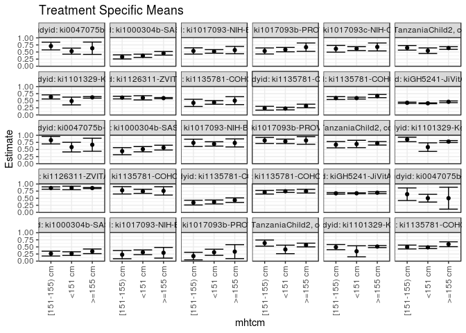

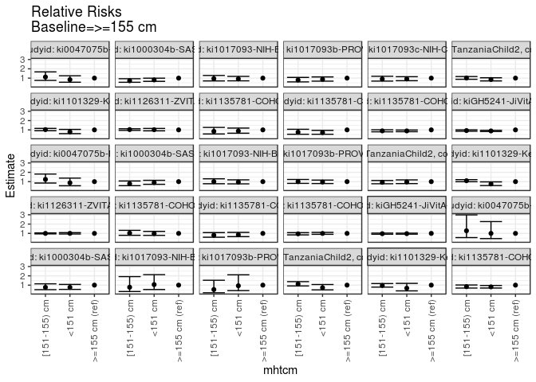

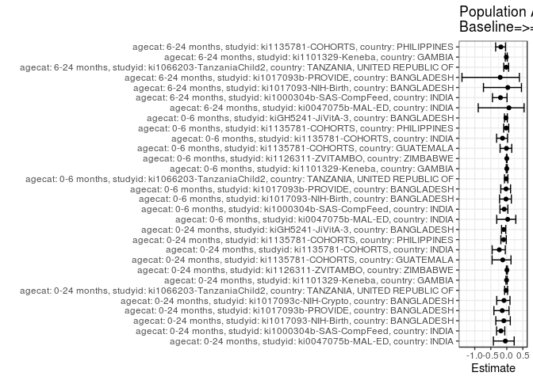

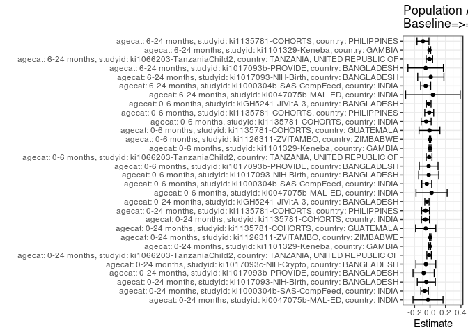

## Results Table

### Parameter: TSM

| agecat | studyid | country | intervention_level | baseline_level | estimate | ci_lower | ci_upper |
| --- | --- | --- | --- | --- | --- | --- | --- |
| 0-24 months | ki0047075b-MAL-ED | INDIA | >=155 cm | NA | 0.6333574 | 0.4153092 | 0.8514055 |
| 0-24 months | ki0047075b-MAL-ED | INDIA | <151 cm | NA | 0.5306218 | 0.4237830 | 0.6374607 |
| 0-24 months | ki0047075b-MAL-ED | INDIA | [151-155) cm | NA | 0.7104210 | 0.5751513 | 0.8456908 |
| 0-24 months | ki1000304b-SAS-CompFeed | INDIA | >=155 cm | NA | 0.4547245 | 0.3915045 | 0.5179444 |
| 0-24 months | ki1000304b-SAS-CompFeed | INDIA | <151 cm | NA | 0.3665723 | 0.3097683 | 0.4233762 |
| 0-24 months | ki1000304b-SAS-CompFeed | INDIA | [151-155) cm | NA | 0.3275562 | 0.2551187 | 0.3999937 |
| 0-24 months | ki1017093-NIH-Birth | BANGLADESH | >=155 cm | NA | 0.5684960 | 0.4394302 | 0.6975617 |
| 0-24 months | ki1017093-NIH-Birth | BANGLADESH | <151 cm | NA | 0.5215418 | 0.4578563 | 0.5852274 |
| 0-24 months | ki1017093-NIH-Birth | BANGLADESH | [151-155) cm | NA | 0.5376001 | 0.4273271 | 0.6478730 |
| 0-24 months | ki1017093b-PROVIDE | BANGLADESH | >=155 cm | NA | 0.6707221 | 0.5229048 | 0.8185393 |
| 0-24 months | ki1017093b-PROVIDE | BANGLADESH | <151 cm | NA | 0.5850732 | 0.5080566 | 0.6620898 |
| 0-24 months | ki1017093b-PROVIDE | BANGLADESH | [151-155) cm | NA | 0.5366728 | 0.4297045 | 0.6436411 |
| 0-24 months | ki1017093c-NIH-Crypto | BANGLADESH | >=155 cm | NA | 0.6786914 | 0.5387562 | 0.8186266 |
| 0-24 months | ki1017093c-NIH-Crypto | BANGLADESH | <151 cm | NA | 0.6200586 | 0.5515792 | 0.6885381 |
| 0-24 months | ki1017093c-NIH-Crypto | BANGLADESH | [151-155) cm | NA | 0.6141327 | 0.4956698 | 0.7325955 |
| 0-24 months | ki1066203-TanzaniaChild2 | TANZANIA, UNITED REPUBLIC OF | >=155 cm | NA | 0.6408170 | 0.5932638 | 0.6883702 |
| 0-24 months | ki1066203-TanzaniaChild2 | TANZANIA, UNITED REPUBLIC OF | <151 cm | NA | 0.5460843 | 0.4472442 | 0.6449243 |
| 0-24 months | ki1066203-TanzaniaChild2 | TANZANIA, UNITED REPUBLIC OF | [151-155) cm | NA | 0.6482537 | 0.5676322 | 0.7288751 |
| 0-24 months | ki1101329-Keneba | GAMBIA | >=155 cm | NA | 0.6191935 | 0.5915890 | 0.6467979 |
| 0-24 months | ki1101329-Keneba | GAMBIA | <151 cm | NA | 0.4897571 | 0.3519623 | 0.6275519 |
| 0-24 months | ki1101329-Keneba | GAMBIA | [151-155) cm | NA | 0.6348667 | 0.5626161 | 0.7071173 |
| 0-24 months | ki1126311-ZVITAMBO | ZIMBABWE | >=155 cm | NA | 0.5931647 | 0.5721723 | 0.6141571 |
| 0-24 months | ki1126311-ZVITAMBO | ZIMBABWE | <151 cm | NA | 0.6033960 | 0.5299433 | 0.6768486 |
| 0-24 months | ki1126311-ZVITAMBO | ZIMBABWE | [151-155) cm | NA | 0.6116426 | 0.5644617 | 0.6588236 |
| 0-24 months | ki1135781-COHORTS | GUATEMALA | >=155 cm | NA | 0.5037677 | 0.3640636 | 0.6434719 |
| 0-24 months | ki1135781-COHORTS | GUATEMALA | <151 cm | NA | 0.4403127 | 0.3771178 | 0.5035076 |
| 0-24 months | ki1135781-COHORTS | GUATEMALA | [151-155) cm | NA | 0.4246956 | 0.2981190 | 0.5512723 |
| 0-24 months | ki1135781-COHORTS | INDIA | >=155 cm | NA | 0.3155178 | 0.2519710 | 0.3790647 |
| 0-24 months | ki1135781-COHORTS | INDIA | <151 cm | NA | 0.2238689 | 0.1771435 | 0.2705943 |
| 0-24 months | ki1135781-COHORTS | INDIA | [151-155) cm | NA | 0.2368933 | 0.1695266 | 0.3042600 |

[output cut: 60 more lines]

### Parameter: E(Y)

| agecat | studyid | country | intervention_level | baseline_level | estimate | ci_lower | ci_upper |
| --- | --- | --- | --- | --- | --- | --- | --- |
| 0-24 months | ki0047075b-MAL-ED | INDIA | NA | NA | 0.6067416 | 0.5268346 | 0.6866486 |
| 0-24 months | ki1000304b-SAS-CompFeed | INDIA | NA | NA | 0.3844086 | 0.3477135 | 0.4211037 |
| 0-24 months | ki1017093-NIH-Birth | BANGLADESH | NA | NA | 0.5201900 | 0.4695846 | 0.5707955 |
| 0-24 months | ki1017093b-PROVIDE | BANGLADESH | NA | NA | 0.5874587 | 0.5306185 | 0.6442990 |
| 0-24 months | ki1017093c-NIH-Crypto | BANGLADESH | NA | NA | 0.6245955 | 0.5705077 | 0.6786833 |
| 0-24 months | ki1066203-TanzaniaChild2 | TANZANIA, UNITED REPUBLIC OF | NA | NA | 0.6283688 | 0.5905159 | 0.6662217 |
| 0-24 months | ki1101329-Keneba | GAMBIA | NA | NA | 0.6152905 | 0.5899139 | 0.6406671 |
| 0-24 months | ki1126311-ZVITAMBO | ZIMBABWE | NA | NA | 0.5959970 | 0.5774555 | 0.6145386 |
| 0-24 months | ki1135781-COHORTS | GUATEMALA | NA | NA | 0.4477212 | 0.3954919 | 0.4999504 |
| 0-24 months | ki1135781-COHORTS | INDIA | NA | NA | 0.2557143 | 0.2227697 | 0.2886589 |
| 0-24 months | ki1135781-COHORTS | PHILIPPINES | NA | NA | 0.6068680 | 0.5823645 | 0.6313715 |
| 0-24 months | kiGH5241-JiVitA-3 | BANGLADESH | NA | NA | 0.4226585 | 0.4115120 | 0.4338051 |
| 0-6 months | ki0047075b-MAL-ED | INDIA | NA | NA | 0.6867470 | 0.5837430 | 0.7897510 |
| 0-6 months | ki1000304b-SAS-CompFeed | INDIA | NA | NA | 0.5228758 | 0.4664267 | 0.5793250 |
| 0-6 months | ki1017093-NIH-Birth | BANGLADESH | NA | NA | 0.7130045 | 0.6535890 | 0.7724200 |
| 0-6 months | ki1017093b-PROVIDE | BANGLADESH | NA | NA | 0.8000000 | 0.7425836 | 0.8574164 |
| 0-6 months | ki1066203-TanzaniaChild2 | TANZANIA, UNITED REPUBLIC OF | NA | NA | 0.7053571 | 0.6558827 | 0.7548316 |
| 0-6 months | ki1101329-Keneba | GAMBIA | NA | NA | 0.7781155 | 0.7468871 | 0.8093439 |
| 0-6 months | ki1126311-ZVITAMBO | ZIMBABWE | NA | NA | 0.8577803 | 0.8416785 | 0.8738820 |
| 0-6 months | ki1135781-COHORTS | GUATEMALA | NA | NA | 0.7500000 | 0.6917133 | 0.8082867 |
| 0-6 months | ki1135781-COHORTS | INDIA | NA | NA | 0.3800425 | 0.3361595 | 0.4239255 |
| 0-6 months | ki1135781-COHORTS | PHILIPPINES | NA | NA | 0.7367021 | 0.7051294 | 0.7682749 |
| 0-6 months | kiGH5241-JiVitA-3 | BANGLADESH | NA | NA | 0.6758591 | 0.6624976 | 0.6892206 |
| 6-24 months | ki0047075b-MAL-ED | INDIA | NA | NA | 0.5368421 | 0.4223932 | 0.6512910 |
| 6-24 months | ki1000304b-SAS-CompFeed | INDIA | NA | NA | 0.2876712 | 0.2441703 | 0.3311721 |
| 6-24 months | ki1017093-NIH-Birth | BANGLADESH | NA | NA | 0.3030303 | 0.2377927 | 0.3682679 |
| 6-24 months | ki1017093b-PROVIDE | BANGLADESH | NA | NA | 0.2764228 | 0.1950773 | 0.3577682 |
| 6-24 months | ki1066203-TanzaniaChild2 | TANZANIA, UNITED REPUBLIC OF | NA | NA | 0.5582656 | 0.5057575 | 0.6107737 |
| 6-24 months | ki1101329-Keneba | GAMBIA | NA | NA | 0.5056295 | 0.4721671 | 0.5390918 |
| 6-24 months | ki1135781-COHORTS | PHILIPPINES | NA | NA | 0.5026681 | 0.4688378 | 0.5364984 |

### Parameter: RR

| agecat | studyid | country | intervention_level | baseline_level | estimate | ci_lower | ci_upper |
| --- | --- | --- | --- | --- | --- | --- | --- |
| 0-24 months | ki0047075b-MAL-ED | INDIA | >=155 cm | >=155 cm | 1.0000000 | 1.0000000 | 1.0000000 |
| 0-24 months | ki0047075b-MAL-ED | INDIA | <151 cm | >=155 cm | 0.8377921 | 0.5615318 | 1.2499660 |
| 0-24 months | ki0047075b-MAL-ED | INDIA | [151-155) cm | >=155 cm | 1.1216749 | 0.7538656 | 1.6689373 |
| 0-24 months | ki1000304b-SAS-CompFeed | INDIA | >=155 cm | >=155 cm | 1.0000000 | 1.0000000 | 1.0000000 |
| 0-24 months | ki1000304b-SAS-CompFeed | INDIA | <151 cm | >=155 cm | 0.8061414 | 0.6547173 | 0.9925873 |
| 0-24 months | ki1000304b-SAS-CompFeed | INDIA | [151-155) cm | >=155 cm | 0.7203399 | 0.5546153 | 0.9355846 |
| 0-24 months | ki1017093-NIH-Birth | BANGLADESH | >=155 cm | >=155 cm | 1.0000000 | 1.0000000 | 1.0000000 |
| 0-24 months | ki1017093-NIH-Birth | BANGLADESH | <151 cm | >=155 cm | 0.9174064 | 0.7084923 | 1.1879232 |
| 0-24 months | ki1017093-NIH-Birth | BANGLADESH | [151-155) cm | >=155 cm | 0.9456532 | 0.6964249 | 1.2840726 |
| 0-24 months | ki1017093b-PROVIDE | BANGLADESH | >=155 cm | >=155 cm | 1.0000000 | 1.0000000 | 1.0000000 |
| 0-24 months | ki1017093b-PROVIDE | BANGLADESH | <151 cm | >=155 cm | 0.8723035 | 0.6744800 | 1.1281483 |
| 0-24 months | ki1017093b-PROVIDE | BANGLADESH | [151-155) cm | >=155 cm | 0.8001419 | 0.5943090 | 1.0772629 |
| 0-24 months | ki1017093c-NIH-Crypto | BANGLADESH | >=155 cm | >=155 cm | 1.0000000 | 1.0000000 | 1.0000000 |
| 0-24 months | ki1017093c-NIH-Crypto | BANGLADESH | <151 cm | >=155 cm | 0.9136091 | 0.7226176 | 1.1550807 |
| 0-24 months | ki1017093c-NIH-Crypto | BANGLADESH | [151-155) cm | >=155 cm | 0.9048777 | 0.6818305 | 1.2008901 |
| 0-24 months | ki1066203-TanzaniaChild2 | TANZANIA, UNITED REPUBLIC OF | >=155 cm | >=155 cm | 1.0000000 | 1.0000000 | 1.0000000 |
| 0-24 months | ki1066203-TanzaniaChild2 | TANZANIA, UNITED REPUBLIC OF | <151 cm | >=155 cm | 0.8521688 | 0.7006950 | 1.0363878 |
| 0-24 months | ki1066203-TanzaniaChild2 | TANZANIA, UNITED REPUBLIC OF | [151-155) cm | >=155 cm | 1.0116050 | 0.8751093 | 1.1693906 |
| 0-24 months | ki1101329-Keneba | GAMBIA | >=155 cm | >=155 cm | 1.0000000 | 1.0000000 | 1.0000000 |
| 0-24 months | ki1101329-Keneba | GAMBIA | <151 cm | >=155 cm | 0.7909596 | 0.5949242 | 1.0515914 |
| 0-24 months | ki1101329-Keneba | GAMBIA | [151-155) cm | >=155 cm | 1.0253123 | 0.9074267 | 1.1585128 |
| 0-24 months | ki1126311-ZVITAMBO | ZIMBABWE | >=155 cm | >=155 cm | 1.0000000 | 1.0000000 | 1.0000000 |
| 0-24 months | ki1126311-ZVITAMBO | ZIMBABWE | <151 cm | >=155 cm | 1.0172487 | 0.8961290 | 1.1547387 |
| 0-24 months | ki1126311-ZVITAMBO | ZIMBABWE | [151-155) cm | >=155 cm | 1.0311515 | 0.9472136 | 1.1225275 |
| 0-24 months | ki1135781-COHORTS | GUATEMALA | >=155 cm | >=155 cm | 1.0000000 | 1.0000000 | 1.0000000 |
| 0-24 months | ki1135781-COHORTS | GUATEMALA | <151 cm | >=155 cm | 0.8740391 | 0.6405020 | 1.1927274 |
| 0-24 months | ki1135781-COHORTS | GUATEMALA | [151-155) cm | >=155 cm | 0.8430386 | 0.5611598 | 1.2665091 |
| 0-24 months | ki1135781-COHORTS | INDIA | >=155 cm | >=155 cm | 1.0000000 | 1.0000000 | 1.0000000 |
| 0-24 months | ki1135781-COHORTS | INDIA | <151 cm | >=155 cm | 0.7095285 | 0.5307029 | 0.9486112 |
| 0-24 months | ki1135781-COHORTS | INDIA | [151-155) cm | >=155 cm | 0.7508079 | 0.5297010 | 1.0642089 |

[output cut: 60 more lines]

### Parameter: PAR

| agecat | studyid | country | intervention_level | baseline_level | estimate | ci_lower | ci_upper |
| --- | --- | --- | --- | --- | --- | --- | --- |
| 0-24 months | ki0047075b-MAL-ED | INDIA | >=155 cm | NA | -0.0266158 | -0.2207555 | 0.1675239 |
| 0-24 months | ki1000304b-SAS-CompFeed | INDIA | >=155 cm | NA | -0.0703159 | -0.1195042 | -0.0211276 |
| 0-24 months | ki1017093-NIH-Birth | BANGLADESH | >=155 cm | NA | -0.0483060 | -0.1650921 | 0.0684802 |
| 0-24 months | ki1017093b-PROVIDE | BANGLADESH | >=155 cm | NA | -0.0832633 | -0.2204214 | 0.0538948 |
| 0-24 months | ki1017093c-NIH-Crypto | BANGLADESH | >=155 cm | NA | -0.0540959 | -0.1823981 | 0.0742062 |
| 0-24 months | ki1066203-TanzaniaChild2 | TANZANIA, UNITED REPUBLIC OF | >=155 cm | NA | -0.0124482 | -0.0416828 | 0.0167864 |
| 0-24 months | ki1101329-Keneba | GAMBIA | >=155 cm | NA | -0.0039030 | -0.0156271 | 0.0078211 |
| 0-24 months | ki1126311-ZVITAMBO | ZIMBABWE | >=155 cm | NA | 0.0028323 | -0.0066675 | 0.0123322 |
| 0-24 months | ki1135781-COHORTS | GUATEMALA | >=155 cm | NA | -0.0560466 | -0.1864942 | 0.0744011 |
| 0-24 months | ki1135781-COHORTS | INDIA | >=155 cm | NA | -0.0598036 | -0.1121306 | -0.0074765 |
| 0-24 months | ki1135781-COHORTS | PHILIPPINES | >=155 cm | NA | -0.0586820 | -0.1093711 | -0.0079928 |
| 0-24 months | kiGH5241-JiVitA-3 | BANGLADESH | >=155 cm | NA | -0.0403722 | -0.0680466 | -0.0126977 |
| 0-6 months | ki0047075b-MAL-ED | INDIA | >=155 cm | NA | 0.0200803 | -0.1814975 | 0.2216581 |
| 0-6 months | ki1000304b-SAS-CompFeed | INDIA | >=155 cm | NA | -0.0425641 | -0.1066254 | 0.0214972 |
| 0-6 months | ki1017093-NIH-Birth | BANGLADESH | >=155 cm | NA | -0.0171914 | -0.1472694 | 0.1128866 |
| 0-6 months | ki1017093b-PROVIDE | BANGLADESH | >=155 cm | NA | -0.0181818 | -0.1399756 | 0.1036120 |
| 0-6 months | ki1066203-TanzaniaChild2 | TANZANIA, UNITED REPUBLIC OF | >=155 cm | NA | -0.0122093 | -0.0497400 | 0.0253214 |
| 0-6 months | ki1101329-Keneba | GAMBIA | >=155 cm | NA | 0.0000497 | -0.0131025 | 0.0132019 |
| 0-6 months | ki1126311-ZVITAMBO | ZIMBABWE | >=155 cm | NA | 0.0003189 | -0.0081320 | 0.0087697 |
| 0-6 months | ki1135781-COHORTS | GUATEMALA | >=155 cm | NA | -0.0075758 | -0.1429684 | 0.1278169 |
| 0-6 months | ki1135781-COHORTS | INDIA | >=155 cm | NA | -0.0506197 | -0.1155964 | 0.0143571 |
| 0-6 months | ki1135781-COHORTS | PHILIPPINES | >=155 cm | NA | -0.0107124 | -0.0687208 | 0.0472959 |
| 0-6 months | kiGH5241-JiVitA-3 | BANGLADESH | >=155 cm | NA | -0.0175471 | -0.0480703 | 0.0129761 |
| 6-24 months | ki0047075b-MAL-ED | INDIA | >=155 cm | NA | 0.0368421 | -0.3162378 | 0.3899220 |
| 6-24 months | ki1000304b-SAS-CompFeed | INDIA | >=155 cm | NA | -0.0567829 | -0.1219797 | 0.0084138 |
| 6-24 months | ki1017093-NIH-Birth | BANGLADESH | >=155 cm | NA | 0.0099129 | -0.1597741 | 0.1796000 |
| 6-24 months | ki1017093b-PROVIDE | BANGLADESH | >=155 cm | NA | -0.0569106 | -0.2862152 | 0.1723941 |
| 6-24 months | ki1066203-TanzaniaChild2 | TANZANIA, UNITED REPUBLIC OF | >=155 cm | NA | -0.0085236 | -0.0506814 | 0.0336342 |
| 6-24 months | ki1101329-Keneba | GAMBIA | >=155 cm | NA | -0.0073089 | -0.0227854 | 0.0081676 |
| 6-24 months | ki1135781-COHORTS | PHILIPPINES | >=155 cm | NA | -0.0916708 | -0.1690785 | -0.0142630 |

### Parameter: PAF

| agecat | studyid | country | intervention_level | baseline_level | estimate | ci_lower | ci_upper |
| --- | --- | --- | --- | --- | --- | --- | --- |
| 0-24 months | ki0047075b-MAL-ED | INDIA | >=155 cm | NA | -0.0438668 | -0.4174891 | 0.2312760 |
| 0-24 months | ki1000304b-SAS-CompFeed | INDIA | >=155 cm | NA | -0.1829197 | -0.3181389 | -0.0615716 |
| 0-24 months | ki1017093-NIH-Birth | BANGLADESH | >=155 cm | NA | -0.0928621 | -0.3418858 | 0.1099484 |
| 0-24 months | ki1017093b-PROVIDE | BANGLADESH | >=155 cm | NA | -0.1417347 | -0.4014998 | 0.0698834 |
| 0-24 months | ki1017093c-NIH-Crypto | BANGLADESH | >=155 cm | NA | -0.0866095 | -0.3127640 | 0.1005845 |
| 0-24 months | ki1066203-TanzaniaChild2 | TANZANIA, UNITED REPUBLIC OF | >=155 cm | NA | -0.0198103 | -0.0674433 | 0.0256971 |
| 0-24 months | ki1101329-Keneba | GAMBIA | >=155 cm | NA | -0.0063433 | -0.0255899 | 0.0125421 |
| 0-24 months | ki1126311-ZVITAMBO | ZIMBABWE | >=155 cm | NA | 0.0047523 | -0.0113191 | 0.0205682 |
| 0-24 months | ki1135781-COHORTS | GUATEMALA | >=155 cm | NA | -0.1251818 | -0.4585309 | 0.1319799 |
| 0-24 months | ki1135781-COHORTS | INDIA | >=155 cm | NA | -0.2338687 | -0.4568494 | -0.0450167 |
| 0-24 months | ki1135781-COHORTS | PHILIPPINES | >=155 cm | NA | -0.0966964 | -0.1835705 | -0.0161989 |
| 0-24 months | kiGH5241-JiVitA-3 | BANGLADESH | >=155 cm | NA | -0.0955196 | -0.1629890 | -0.0319643 |
| 0-6 months | ki0047075b-MAL-ED | INDIA | >=155 cm | NA | 0.0292398 | -0.3137924 | 0.2827060 |
| 0-6 months | ki1000304b-SAS-CompFeed | INDIA | >=155 cm | NA | -0.0814038 | -0.2116000 | 0.0348017 |
| 0-6 months | ki1017093-NIH-Birth | BANGLADESH | >=155 cm | NA | -0.0241112 | -0.2238690 | 0.1430425 |
| 0-6 months | ki1017093b-PROVIDE | BANGLADESH | >=155 cm | NA | -0.0227273 | -0.1868832 | 0.1187245 |
| 0-6 months | ki1066203-TanzaniaChild2 | TANZANIA, UNITED REPUBLIC OF | >=155 cm | NA | -0.0173094 | -0.0719787 | 0.0345719 |
| 0-6 months | ki1101329-Keneba | GAMBIA | >=155 cm | NA | 0.0000639 | -0.0169826 | 0.0168246 |
| 0-6 months | ki1126311-ZVITAMBO | ZIMBABWE | >=155 cm | NA | 0.0003717 | -0.0095291 | 0.0101754 |
| 0-6 months | ki1135781-COHORTS | GUATEMALA | >=155 cm | NA | -0.0101010 | -0.2077661 | 0.1552139 |
| 0-6 months | ki1135781-COHORTS | INDIA | >=155 cm | NA | -0.1331948 | -0.3179180 | 0.0256371 |
| 0-6 months | ki1135781-COHORTS | PHILIPPINES | >=155 cm | NA | -0.0145411 | -0.0964483 | 0.0612475 |
| 0-6 months | kiGH5241-JiVitA-3 | BANGLADESH | >=155 cm | NA | -0.0259626 | -0.0721429 | 0.0182285 |
| 6-24 months | ki0047075b-MAL-ED | INDIA | >=155 cm | NA | 0.0686275 | -0.8916940 | 0.5414402 |
| 6-24 months | ki1000304b-SAS-CompFeed | INDIA | >=155 cm | NA | -0.1973883 | -0.4459873 | 0.0084707 |
| 6-24 months | ki1017093-NIH-Birth | BANGLADESH | >=155 cm | NA | 0.0327127 | -0.7271701 | 0.4582788 |
| 6-24 months | ki1017093b-PROVIDE | BANGLADESH | >=155 cm | NA | -0.2058824 | -1.3990080 | 0.3938527 |
| 6-24 months | ki1066203-TanzaniaChild2 | TANZANIA, UNITED REPUBLIC OF | >=155 cm | NA | -0.0152681 | -0.0937453 | 0.0575784 |
| 6-24 months | ki1101329-Keneba | GAMBIA | >=155 cm | NA | -0.0144551 | -0.0455662 | 0.0157303 |
| 6-24 months | ki1135781-COHORTS | PHILIPPINES | >=155 cm | NA | -0.1823684 | -0.3471050 | -0.0377774 |